# Grade-keeping DB

2 de abril 2016

## DB

El origen de la DB es:

http://www.kitebird.com/mysql-book/

**Propietario original: Paul DuBois**

MySQL; Paul DuBois; 2013; Inglés, Addison-Wesley Professional, 5ta edición.

## Grade-keeping proyect. Requerimientos

- Registrar las calificaciones de un conjunto de alumnos
- Para cada examen o prueba almacenar la calificación
- La calificación final involucra promedios ponderados `:D :D` de las pruebas y de los examenes
- Registrar las faltas de los alumnos

## Grade-keeping proyect

- La DB cuenta con 4 tablas, con registros de las calificaciones obtenidas por un conjunto de alumnos en una asignatura.
- El modelo entidad-relación de la DB cuenta con una relación muchos-muchos.

## Diagrama entidad-relación

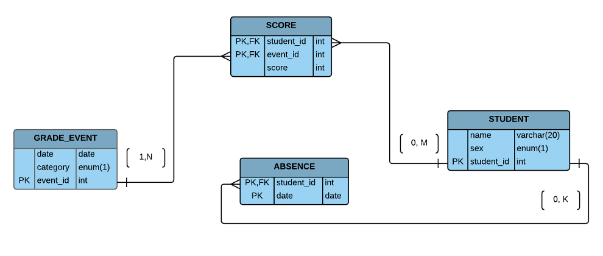

## Implementación

## Renombramos las tablas

```java
    RENAME TABLE absence TO ABSENCE;
    RENAME TABLE grade_event TO GRADE_EVENT;
    RENAME TABLE score TO SCORE;
    RENAME TABLE student TO STUDENT;
```

## DATOS

```
SELECT * FROM ABSENCE LIMIT 6;          SELECT * FROM GRADE_EVENT LIMIT 6;
+------------+------------+             +------------+----------+----------+
| student_id | date       |             | date       | category | event_id |
+------------+------------+             +------------+----------+----------+
|          3 | 2012-09-03 |             | 2012-09-03 | Q        |        1 |
|          5 | 2012-09-03 |             | 2012-09-06 | Q        |        2 |
|         10 | 2012-09-06 |             | 2012-09-09 | T        |        3 |
|         10 | 2012-09-09 |             | 2012-09-16 | Q        |        4 |
|         17 | 2012-09-07 |             | 2012-09-23 | Q        |        5 |
|         20 | 2012-09-07 |             | 2012-10-01 | T        |        6 |
+------------+------------+             +------------+----------+----------+
```

## DATOS

```
SELECT * FROM SCORE LIMIT 6;            SELECT * FROM STUDENT LIMIT 6;
+------------+----------+-------+       +--------+-----+------------+
| student_id | event_id | score |       | name   | sex | student_id |
+------------+----------+-------+       +--------+-----+------------+
|          1 |        1 |    20 |       | Megan  | F   |          1 |
|          3 |        1 |    20 |       | Joseph | M   |          2 |
|          4 |        1 |    18 |       | Kyle   | M   |          3 |
|          5 |        1 |    13 |       | Katie  | F   |          4 |
|          6 |        1 |    18 |       | Abby   | F   |          5 |
|          7 |        1 |    14 |       | Nathan | M   |          6 |
+------------+----------+-------+       +--------+-----+------------+
```

## Comentarios al modelo

- El supuesto de aplicar dos pruebas en un mismo día `:(`

  ```
  CREATE TABLE grade_event
  {
  date        DATE NOT NULL,
  category    ENUM(´T´, ´Q´,) NOT NULL,
  event_id    INT UNSIGNED NOT NULL AUTO_INCREMENT, #en lugar fecha y permitir sólo uno
  PRIMARY KEY(event_id)
  }
  ```

## Comentarios al modelo

- Id de los estudiantes son números, permite un ordenamiento más rápido (cuando sea posible definirlo)

  ```
  CREATE TABLE student
  {
  name        VARCHAR(20) NOT NULL,
  sex         ENUM(´F´, ´M´,) NOT NULL,
  student_id  INT UNSIGNED NOT NULL AUTO_INCREMENT,
  PRIMARY KEY(student_id)
  }
  ```

## Comentarios al modelo

- Idealización de los datos al ser el campo \(score\) de la tabla SCORE de tipo INT, pero ahorra espacio.
- La llave primaria de la tabla ABSENCE es compuesta, lo que no permitiría que un alumno falte dos veces en el mismo día

[figure not shown]

##

Obtener las calificaciones de los muchachos

## Vistas (la primera)

Las calificaciones de los alumnos en el curso

```
CREATE VIEW subCal AS
SELECT  name, score, category
FROM GRADE_EVENT, SCORE,STUDENT
WHERE  SCORE.student_id = STUDENT.student_id
AND GRADE_EVENT.event_id = SCORE.event_id;
```

## Vistas (las siguientes n)

```
CREATE VIEW ssubCal AS
SELECT name,sum(score) score,category
FROM subCal  GROUP BY name,category;
Create view s1 as
select name, score
from ssubCal where category='T';
Create view s2 as
select name, score
from ssubCal where category='Q';
```

## Vista final

```
CREATE VIEW foo AS
select s1.name,(s1.score/200)*.5+(s2.score/80)*.5
from s1 inner join s2
where s1.name=s2.name;
mysql> select * from foo;
+--------+------------------------------------+
| name   | (s1.score/200)*.5+(s2.score/80)*.5 |
+--------+------------------------------------+
| Abby   |                            0.87875 |
| Aubrey |                            0.70500 |
| Avery  |                            0.59500 |
| Becca  |                            0.81500 |
| Ben    |                            0.71250 |
| Carter |                            0.54375 |
| Colin  |                            0.76500 |
+--------+------------------------------------+
```

## Procedure

```
delimiter //
drop procedure if exists Calificaciones;
create procedure Calificaciones ( in nombre varchar(20))
begin
declare examenes int;
declare cuestionarios int;
SELECT  sum( score)  into examenes  FROM GRADE_EVENT, SCORE,STUDENT
WHERE  SCORE.student_id = STUDENT.student_id
AND GRADE_EVENT.event_id = SCORE.event_id
and name=nombre AND category='T';
SELECT  sum( score)  into cuestionarios FROM GRADE_EVENT, SCORE,STUDENT
WHERE  SCORE.student_id = STUDENT.student_id
AND GRADE_EVENT.event_id = SCORE.event_id
and name=nombre AND category='Q';
select( (examenes/200)*.5+(cuestionarios/80)*.5);
end;
delimiter ;
```

## Outputs

```
mysql> call Calificaciones('Will');
+--------------------------------------------+
| ( (examenes/200)*.5+(cuestionarios/80)*.5) |
+--------------------------------------------+
|                                    0.63875 |
+--------------------------------------------+
mysql> call Calificaciones('Emily');
+--------------------------------------------+
| ( (examenes/200)*.5+(cuestionarios/80)*.5) |
+--------------------------------------------+
|                                    0.75500 |
+--------------------------------------------+
```

## Resultados y Base de datos con R!!!

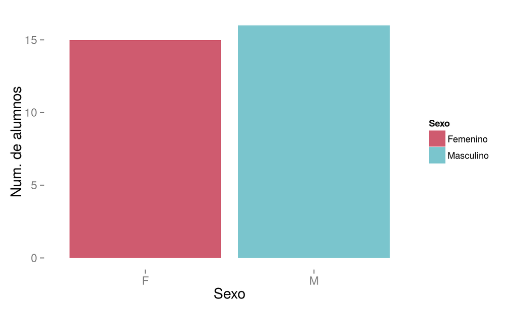

## Resultados y Base de datos con R!!!

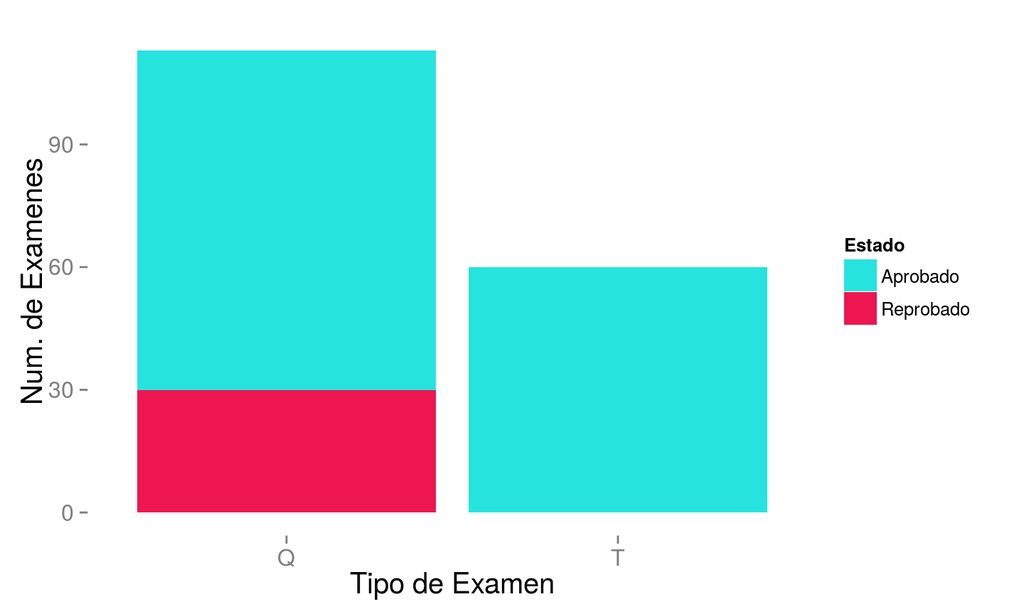

## Resultados y Base de datos con R!!!

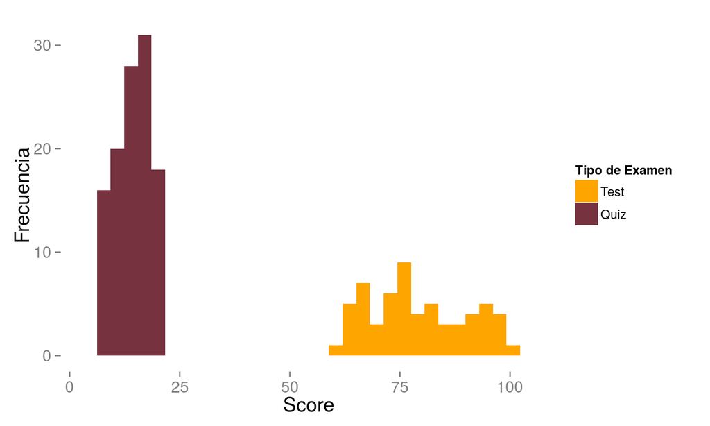